# AtacAnnoR label corrector

Lejin Tian

2023-03-06

AtacAnnoR provides a function based on maximum a posteriori (MAP) to improve the annotation accuracy when multiple references are used.

Briefly speaking, for a given target cluster we identify all candidate clusters that have labels in common with the target cluster and compute a posterior probability for each.

According to Bayes’ theorem, the posteriori probability is determined by the priori probability of the candidate cluster and the likelihood that cells in the candidate cluster is falsely assigned to the target cluster.

The former is equivalent to the proportion of all query cells in this cluster, and the latter can be inferred by calculating the percentage of cells in the candidate cluster that are very similar to cells in the target cluster based on their meta-program profiles.

## Load required packages and datasets

```r
library(AtacAnnoR)
library(Seurat)
```

```r
library(ggplot2)
library(DT)
setwd('~/txmdata/scATAC_seq/AtacAnnoR')
SeuratObj_ATAC <- readRDS('./data/10X-Multiome/SeuratObj/SeuratObj_ATAC.RDS')
AtacAnnoR_pred_list <- readRDS('./data/tools_pred/AtacAnnoR_pred_list.RDS')
```

## Construct a prediction data frame

Each row represents a query cell and each column represents the labels predicted by a specific reference.

```r
pred_df <- data.frame(Hao = AtacAnnoR_pred_list$Hao,
                      Stephenson = AtacAnnoR_pred_list$Stephenson,
                      Wilk = AtacAnnoR_pred_list$Wilk,
                      Zhu = AtacAnnoR_pred_list$Zhu,
                      Monaco = AtacAnnoR_pred_list$Monaco)
head(pred_df)
```

```
##         Hao Stephenson   Wilk                   Zhu    Monaco
## 1 CD4 Naive  CD4.Naive CD4n T         Naive T cells CD4_naive
## 2   CD4 TCM     CD4.EM CD4m T Activated CD4 T cells       Th2
## 3 CD4 Naive  CD4.Naive CD4n T         Naive T cells CD4_naive
## 4 CD8 Naive  CD8.Naive CD4n T         Naive T cells CD8_naive
## 5 CD4 Naive  CD4.Naive CD4n T         Naive T cells CD4_naive
## 6 CD8 Naive  CD8.Naive CD4n T         Naive T cells CD8_naive
```

## Run label corrector

```r
merged_laels <- get_merged_labels(pred_df)
query_nmf_embedding <- SeuratObj_ATAC@reductions[['nmf']]@cell.embeddings
OUT <- correct_labels(merged_laels,query_nmf_embedding)
```

```
## Cluster number before correction: 287
```

```
## Reference number: 5
```

```
## Max edit distance: 4
```

```
## Cluster number after correction: 23
```

### View merged label index after correction

```r
SeuratObj_ATAC$corrected_merged_labels_idx <- OUT$corrected_merged_labels_idx
```

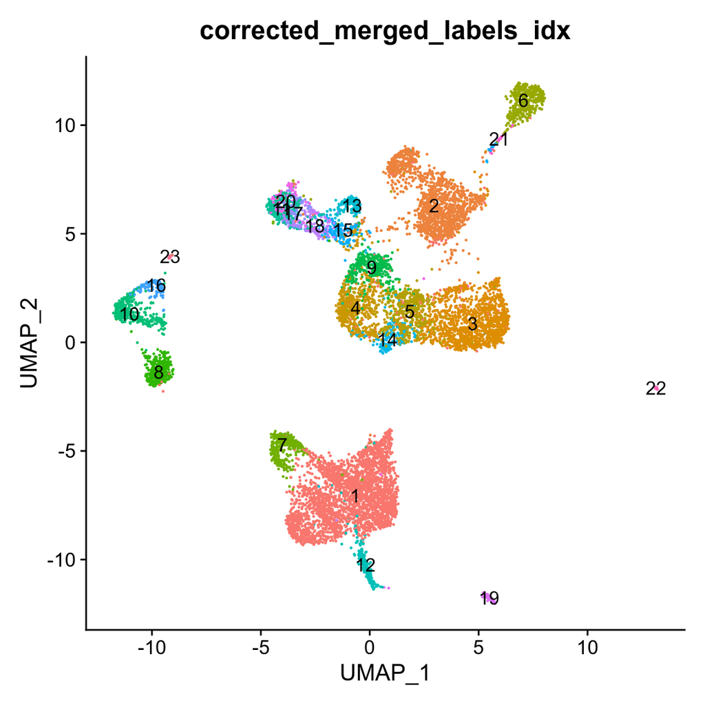

```r
DimPlot(SeuratObj_ATAC,group.by = 'corrected_merged_labels_idx',label = T) + NoLegend()
```

### View merged label index and its corresponding merged label name

```r
datatable(OUT$label_idx_df,options = list(pageLength = 25))
```

|  | label | idx | num |
| --- | --- | --- | --- |
| 1 | 1CD14 Mono1=2CD14.mono2=3CD14 Monocyte3=4Monocytes4=5C_mono5 | 1 | 2921 |
| 2 | 1CD8 Naive1=2CD8.Naive2=3CD4n T3=4Naive T cells4=5CD8_naive5 | 2 | 1463 |
| 3 | 1CD4 Naive1=2CD4.Naive2=3CD4n T3=4Naive T cells4=5CD4_naive5 | 3 | 1346 |
| 4 | 1CD4 TCM1=2CD4.EM2=3CD4m T3=4Activated CD4 T cells4=5Th25 | 4 | 640 |
| 5 | 1CD4 TCM1=2CD4.EM2=3CD4m T3=4Activated CD4 T cells4=5TFH5 | 5 | 489 |
| 6 | 1NK1=2NK2=3NK3=4NKs4=5NK5 | 6 | 443 |
| 7 | 1CD16 Mono1=2CD16.mono2=3CD16 Monocyte3=4Monocytes4=5NC_mono5 | 7 | 393 |
| 8 | 1B naive1=2B_naive2=3B3=4Naive B cells4=5B_naive5 | 8 | 365 |
| 9 | 1CD4 TCM1=2CD4.IL222=3CD4m T3=4Activated CD4 T cells4=5Th175 | 9 | 365 |
| 10 | 1B intermediate1=2B_non-switched_memory2=3B3=4Memory B cells4=5B_NSM5 | 10 | 354 |

[output cut: 13 more lines]

### View label correct rule

```r
datatable(OUT$correct_rule)
```

|  | before | freq | after | changed |
| --- | --- | --- | --- | --- |
| 1 | 1CD14 Mono1=2CD14.mono2=3CD14 Monocyte3=4Monocytes4=5C_mono5 | 2835 | 1CD14 Mono1=2CD14.mono2=3CD14 Monocyte3=4Monocytes4=5C_mono5 | False |
| 2 | 1CD8 Naive1=2CD8.Naive2=3CD4n T3=4Naive T cells4=5CD8_naive5 | 1365 | 1CD8 Naive1=2CD8.Naive2=3CD4n T3=4Naive T cells4=5CD8_naive5 | False |
| 3 | 1CD4 Naive1=2CD4.Naive2=3CD4n T3=4Naive T cells4=5CD4_naive5 | 992 | 1CD4 Naive1=2CD4.Naive2=3CD4n T3=4Naive T cells4=5CD4_naive5 | False |
| 4 | 1CD4 TCM1=2CD4.EM2=3CD4m T3=4Activated CD4 T cells4=5Th25 | 508 | 1CD4 TCM1=2CD4.EM2=3CD4m T3=4Activated CD4 T cells4=5Th25 | False |
| 5 | 1NK1=2NK2=3NK3=4NKs4=5NK5 | 385 | 1NK1=2NK2=3NK3=4NKs4=5NK5 | False |
| 6 | 1CD16 Mono1=2CD16.mono2=3CD16 Monocyte3=4Monocytes4=5NC_mono5 | 365 | 1CD16 Mono1=2CD16.mono2=3CD16 Monocyte3=4Monocytes4=5NC_mono5 | False |
| 7 | 1CD4 TCM1=2CD4.EM2=3CD4m T3=4Activated CD4 T cells4=5TFH5 | 365 | 1CD4 TCM1=2CD4.EM2=3CD4m T3=4Activated CD4 T cells4=5TFH5 | False |
| 8 | 1B naive1=2B_naive2=3B3=4Naive B cells4=5B_naive5 | 323 | 1B naive1=2B_naive2=3B3=4Naive B cells4=5B_naive5 | False |
| 9 | 1B intermediate1=2B_non-switched_memory2=3B3=4Memory B cells4=5B_NSM5 | 232 | 1B intermediate1=2B_non-switched_memory2=3B3=4Memory B cells4=5B_NSM5 | False |
| 10 | 1cDC1=2DC2=3DC3=4DCs4=5mDC5 | 198 | 1cDC1=2DC2=3DC3=4DCs4=5mDC5 | False |

[output cut: 277 more lines]

### Check the accuracy after correction compared to the original accuracy in terms of each reference

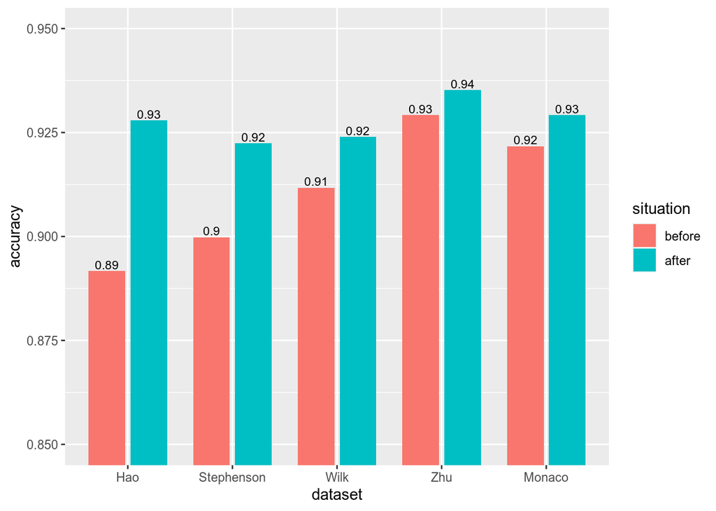

```r
datasets <- c('Hao','Stephenson','Wilk','Zhu','Monaco')
names(OUT$each_corrected_df) <- datasets
out_df <- c()
for(dataset in datasets){
  GML <- AtacAnnoR:::GET_GML(dataset)
  before_accuracy <- get_benchmark(GML(SeuratObj_ATAC$true),GML(pred_df[[dataset]]))[1]
  after_accuracy <- get_benchmark(GML(SeuratObj_ATAC$true),GML(OUT$each_corrected_df[[dataset]]))[1]
  out_df <- rbind(out_df,
                  c(accuracy = before_accuracy,dataset = dataset,situation = 'before'),
                  c(accuracy = after_accuracy,dataset = dataset,situation = 'after'))
}
out_df <- as.data.frame(out_df)
out_df$accuracy <- as.numeric(out_df$accuracy)
out_df$dataset <- factor(out_df$dataset, levels = datasets)
out_df$situation <- factor(out_df$situation,levels = c('before','after'))
ggplot(out_df,aes(x = dataset, y = accuracy, fill = situation, group = situation)) +
  geom_bar(stat = "identity", position = position_dodge(width = 0.8, preserve = "single"), width = 0.7) +
  geom_text(aes(label = round(accuracy, 2)), size = 3, position = position_dodge(0.8), vjust = -0.2) +
  coord_cartesian(ylim = c(0.85, 0.95))
```